# P2. Distribución espacial de la red EMT

Análisis Exploratorio de Datos · Máster en Ciencia de Datos, Universitat de València

Carlos Galdámez Huertas

# 1 Introducción

La pregunta P2 del proyecto es: **¿cómo está distribuida espacialmente la red de autobuses EMT en Valencia?** Estudiamos la posición de las paradas activas, las líneas que figuran en cada una y su concentración espacial. Una parada activa es una parada marcada como operativa (`suprimida = 0`). El número de líneas distintas por parada cuenta los códigos de línea que figuran en ella: por ejemplo, si una parada tiene las líneas 10, 11 y 28, su valor es 3. Es una medida de diversidad de líneas disponibles, no del número de autobuses que pasan ni de su frecuencia, demanda o calidad de servicio.

# 2 Datos y preparación

La capa EMT del [portal de datos abiertos del Ayuntamiento de València](https://opendata.vlci.valencia.es/dataset/emt) proporciona identificador de parada, estado, denominación, líneas y geometría puntual. El archivo original `data/raw/emt.json` está expresado en ETRS89 / UTM zona 30N (EPSG:25830, unidades métricas). La consulta municipal del 2 de noviembre de 2026 devolvió los mismos 1.155 identificadores que la copia suministrada. Se desconoce la fecha exacta de descarga original; la capa puede cambiar con el tiempo. La fuente describe líneas regulares o nocturnas, pero los resultados se refieren únicamente a los códigos presentes en esta copia.

Se comprueban identificadores únicos, coordenadas, geometrías y valores perdidos. Se seleccionan las paradas con `suprimida = 0`; para contar líneas se separa la lista por comas, se eliminan espacios y se conservan códigos como texto. Se elimina cualquier pareja parada-línea repetida. Una lista ausente se mantiene desconocida, no se sustituye por cero; tampoco se imputan direcciones o códigos de vía. El código de importación, limpieza y análisis se incluye en los siguientes bloques. El archivo original se conserva en `data/raw`, y las paradas y relaciones procesadas se guardan en `data/processed` para su integración con el tráfico.

```r
dir.create("data/processed", recursive = TRUE, showWarnings = FALSE)
dir.create("figures", showWarnings = FALSE)
# Importación y limpieza de la capa EMT. Ejecutar desde la raíz ProyectoAED.
paquetes <- c("jsonlite", "dplyr", "tidyr", "stringr", "sf", "ggplot2")
faltan <- paquetes[!vapply(paquetes, requireNamespace, logical(1), quietly = TRUE)]
if (length(faltan)) stop("Instale los paquetes necesarios: ", paste(faltan, collapse = ", "))
library(dplyr)
library(tidyr)
library(stringr)
library(sf)
library(ggplot2)

archivo_emt <- "data/raw/emt.json"
if (!file.exists(archivo_emt)) stop("No se encuentra ", archivo_emt)
original <- jsonlite::fromJSON(archivo_emt, simplifyVector = TRUE)
if (!identical(as.integer(original$spatialReference$wkid), 25830L)) stop("CRS inesperado")
atributos <- original$features$attributes
coordenadas <- original$features$geometry
stopifnot(nrow(atributos) == nrow(coordenadas), !anyDuplicated(atributos$gid),
          !anyDuplicated(atributos$id_parada), !anyNA(atributos$id_parada))
calidad <- data.frame(variable = names(atributos),
  ausentes = vapply(atributos, function(x) sum(is.na(x) | (is.character(x) & trimws(x) == "")), integer(1)))

# Una fila representa una parada. Las líneas vacías se consideran desconocidas,
# no cero. Los códigos se conservan como texto (por ejemplo, C1).
paradas_tabla <- atributos %>%
  mutate(across(where(is.character), ~ na_if(str_squish(.x), "")),
         x = coordenadas$x, y = coordenadas$y)
if (anyNA(paradas_tabla$x) || anyNA(paradas_tabla$y)) stop("Hay paradas sin coordenadas")
paradas_activas <- paradas_tabla %>% filter(suprimida == 0)
lineas_parada <- paradas_activas %>%
  select(id_parada, lineas) %>% filter(!is.na(lineas)) %>%
  separate_rows(lineas, sep = ",") %>%
  mutate(linea = str_to_upper(str_squish(lineas))) %>%
  filter(!is.na(linea), linea != "") %>% select(id_parada, linea) %>% distinct()
conteo <- lineas_parada %>% count(id_parada, name = "n_lineas")
paradas_activas <- paradas_activas %>% left_join(conteo, by = "id_parada")
paradas_sf <- st_as_sf(paradas_activas, coords = c("x", "y"), crs = 25830, remove = FALSE)
if (!all(st_is_valid(paradas_sf))) stop("Existen geometrías no válidas")
write.csv(lineas_parada, "data/processed/emt_parada_linea.csv", row.names = FALSE, na = "")
st_write(paradas_sf, "data/processed/emt_paradas.gpkg", layer = "paradas_activas", delete_dsn = TRUE, quiet = TRUE)
```

```r
# Análisis de la red EMT. Ejecutar desde la raíz del proyecto.

resumen <- paradas_activas %>% summarise(
  paradas = n(), lineas_distintas = n_distinct(lineas_parada$linea),
  media = mean(n_lineas, na.rm = TRUE), mediana = median(n_lineas, na.rm = TRUE),
  desviacion = sd(n_lineas, na.rm = TRUE), Q1 = quantile(n_lineas, .25, na.rm = TRUE),
  Q3 = quantile(n_lineas, .75, na.rm = TRUE), maximo = max(n_lineas, na.rm = TRUE))
distribucion_paradas <- paradas_activas %>% count(n_lineas, name = "paradas") %>%
  mutate(porcentaje = 100 * paradas / sum(paradas))
limite_superior <- unname(quantile(paradas_activas$n_lineas, .75, na.rm=TRUE) +
  1.5 * IQR(paradas_activas$n_lineas, na.rm=TRUE))
ranking <- paradas_activas %>% select(id_parada, denominacion, lineas, n_lineas) %>%
  arrange(desc(n_lineas), id_parada)
ranking_lineas <- lineas_parada %>% count(linea, name = "n_paradas") %>% arrange(desc(n_paradas), linea)
atipicas <- ranking %>% filter(n_lineas > limite_superior)

# Malla métrica de 250 m: cada punto se asigna a la primera celda coincidente.
# Solo se representan celdas ocupadas; no existe un límite municipal en los datos.
malla <- st_make_grid(paradas_sf, cellsize = 250, square = TRUE)
indices <- st_intersects(paradas_sf, malla)
if (any(lengths(indices) == 0)) stop("Una parada queda fuera de la malla")
cuentas <- table(vapply(indices, `[`, integer(1), 1L))
ocupadas <- as.integer(names(cuentas))
celdas <- st_sf(celda = ocupadas, paradas = as.integer(cuentas), geometry = malla[ocupadas]) %>%
  mutate(densidad_km2 = paradas / 0.25^2)
stopifnot(sum(celdas$paradas) == nrow(paradas_sf), nrow(lineas_parada) == sum(paradas_activas$n_lineas, na.rm=TRUE))

tema <- theme_minimal(base_size = 11)
p_hist <- ggplot(paradas_activas, aes(n_lineas)) + geom_bar(fill="#2878a5") +
  scale_x_continuous(breaks=sort(unique(paradas_activas$n_lineas))) +
  labs(title="Líneas distintas por parada activa", x="Número de líneas", y="Número de paradas") + tema
p_mapa <- ggplot(paradas_sf) + geom_sf(aes(colour=n_lineas), size=1.1, alpha=.8) +
  scale_colour_viridis_c(option="plasma", na.value="grey70") +
  labs(title="Distribución de paradas EMT", subtitle="Cada punto representa una parada activa", colour="Líneas") + tema
p_densidad <- ggplot(celdas) + geom_sf(aes(fill=paradas), colour=NA) +
  scale_fill_viridis_c(option="magma") +
  labs(title="Concentración de paradas EMT", subtitle="Cuadrículas ocupadas de 250 × 250 m", fill="Paradas") + tema
p_top <- ranking %>% slice_head(n=10) %>%
  mutate(etiqueta = denominacion) %>%
  ggplot(aes(x=reorder(etiqueta, n_lineas), y=n_lineas)) +
  geom_col(fill="#2878a5") + coord_flip() +
  labs(title="Paradas con más líneas distintas", x=NULL, y="Número de líneas") + tema
for (nombre in c("hist", "mapa", "densidad", "top"))
  ggsave(paste0("figures/emt_",nombre,".png"), get(paste0("p_",nombre)), width=8, height=5, dpi=150)
```

```r
knitr::kable(calidad, col.names = c("Variable", "Valores ausentes"),
             caption = "Valores ausentes en los atributos originales")
```

Valores ausentes en los atributos originales

|  | Variable | Valores ausentes |
| --- | --- | --- |
| gid | gid | 0 |
| id_parada | id_parada | 0 |
| codvia | codvia | 111 |
| numportal | numportal | 3 |
| suprimida | suprimida | 0 |
| denominacion | denominacion | 0 |
| lineas | lineas | 0 |
| proximas_llegadas | proximas_llegadas | 0 |

```r
cat("Registros originales:", nrow(atributos), "\n")
```

```
Registros originales: 1155
```

```r
cat("Identificadores de parada duplicados:", sum(duplicated(atributos$id_parada)), "\n")
```

```
Identificadores de parada duplicados: 0
```

```r
cat("Paradas activas analizadas:", nrow(paradas_activas), "\n")
```

```
Paradas activas analizadas: 1155
```

`codvia` presenta 111 valores ausentes y `numportal`, 3. Como estas variables no son necesarias para contar líneas ni situar los puntos, se conservan sin imputación. No hay duplicados de identificador ni puntos sin coordenadas en esta copia.

# 3 Resultados

## 3.1 Número de paradas y líneas

```r
knitr::kable(resumen, digits = 2, caption = "Resumen de las paradas activas y sus líneas")
```

Resumen de las paradas activas y sus líneas

| paradas | lineas_distintas | media | mediana | desviacion | Q1 | Q3 | maximo |
| --- | --- | --- | --- | --- | --- | --- | --- |
| 1155 | 46 | 1.88 | 1 | 1.33 | 1 | 2 | 14 |

```r
knitr::kable(distribucion_paradas, digits = 2, caption = "Distribución del número de líneas por parada")
```

Distribución del número de líneas por parada

| n_lineas | paradas | porcentaje |
| --- | --- | --- |
| 1 | 598 | 51.77 |
| 2 | 333 | 28.83 |
| 3 | 115 | 9.96 |
| 4 | 50 | 4.33 |
| 5 | 31 | 2.68 |
| 6 | 14 | 1.21 |
| 7 | 7 | 0.61 |
| 8 | 2 | 0.17 |
| 9 | 3 | 0.26 |
| 12 | 1 | 0.09 |
| 14 | 1 | 0.09 |

Se identifican **1155 paradas activas** y **46 códigos de línea distintos**. La media es 1.88 líneas por parada y la mediana es 1. Un total de 598 paradas (51.8 %) tienen una sola línea. La media superior a la mediana refleja una distribución con una cola hacia paradas con mayor número de líneas.

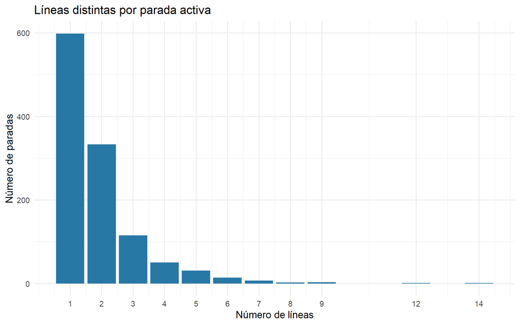

Distribución de líneas distintas por parada activa.

```r
p_hist
```

## 3.2 Paradas de mayor conectividad y observaciones atípicas

```r
knitr::kable(head(ranking, 10), caption = "Diez paradas con más líneas; los empates se ordenan por identificador")
```

Diez paradas con más líneas; los empates se ordenan por identificador

| id_parada | denominacion | lineas | n_lineas |
| --- | --- | --- | --- |
| 2277 | Xàtiva - Institut Lluís Vives (2277) | 10,11,28,31,59,60,62,7,70,71,72,73,9,C1 | 14 |
| 2281 | Pintor Sorolla (2281) | 10,11,16,26,31,32,4,6,70,71,8,81 | 12 |
| 773 | Plaça del Temple (773) | 11,16,26,28,6,80,94,95,C1 | 9 |
| 814 | Jesús - Pare Jofré (814) | 10,11,27,31,59,63,67,71,9 | 9 |
| 2257 | Palau de Justícia (2257) | 11,16,26,31,32,6,70,71,81 | 9 |
| 764 | Plaça d’Amèrica - Pont d’Aragó (764) | 10,12,23,24,25,4,94,95 | 8 |
| 2227 | Carrer de la Pau (2227) | 11,16,26,31,32,4,6,70 | 8 |
| 158 | Blasco Ibáñez - Facultat de Psicologia (158) | 12,30,31,71,79,81,89 | 7 |
| 338 | Museu de Belles Arts (338) | 11,16,26,6,79,94,95 | 7 |
| 1020 | Metro Alameda (1020) | 11,16,26,6,70,94,95 | 7 |

La parada con más líneas es **Xàtiva - Institut Lluís Vives (2277)**, con 14, seguida de **Pintor Sorolla (2281)**, con 12. El ranking completo de paradas está disponible en el objeto `ranking` y el de líneas en `ranking_lineas`. Contar paradas por línea no equivale a medir la longitud de su recorrido.

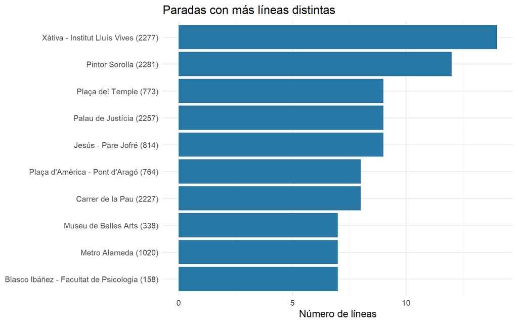

Diez paradas con mayor número de líneas diferentes.

```r
p_top
```

Para señalar valores elevados se usa la regla descriptiva de Tukey: Q3 + 1,5 × rango intercuartílico. El umbral es 3.5 líneas y aparecen 109 paradas por encima de él. Esta regla señala observaciones para examinar, no errores: en una variable discreta y asimétrica puede marcar muchas paradas. No se eliminan ni se imputan, pues no existe evidencia de que sean incorrectas.

## 3.3 Paradas por línea y líneas que coinciden en una parada

Cada código de línea puede aparecer en varias paradas. Contamos cuántas **paradas activas diferentes** tiene asociadas cada línea en esta copia. El resultado puede consultarse para una línea concreta cambiando el valor de `linea_consulta`; no mide la longitud del trayecto ni el número de vehículos o viajes.

```r
knitr::kable(head(ranking_lineas, 10),
             col.names = c("Línea", "Paradas activas"),
             caption = "Las diez líneas con más paradas registradas")
```

Las diez líneas con más paradas registradas

| Línea | Paradas activas |
| --- | --- |
| 23 | 85 |
| 99 | 84 |
| 92 | 72 |
| 95 | 71 |
| 31 | 67 |
| 6 | 62 |
| 71 | 61 |
| 98 | 60 |
| 10 | 58 |
| 64 | 58 |

```r
linea_consulta <- "23"
paradas_linea <- lineas_parada %>%
  filter(linea == linea_consulta) %>%
  left_join(paradas_activas %>% select(id_parada, denominacion), by = "id_parada") %>%
  arrange(id_parada)
cat("Línea", linea_consulta, ":", nrow(paradas_linea), "paradas activas registradas\n")
```

```
Línea 23 : 85 paradas activas registradas
```

```r
knitr::kable(head(paradas_linea, 10), caption = "Primeras paradas registradas para la línea seleccionada")
```

Primeras paradas registradas para la línea seleccionada

| id_parada | linea | denominacion |
| --- | --- | --- |
| 585 | 23 | Forn d’Alcedo (585) |
| 663 | 23 | El Tremolar - Crist del Refugi (663) |
| 664 | 23 | Crist del Refugi - Del Remolí (664) |
| 665 | 23 | Crist del Refugi - Carretera del Pi (665) |
| 666 | 23 | Mare de Déu de Lepant (parell) - Escultor Frederic Siurana (666) |
| 668 | 23 | Major de Castellar - Camí del Ribàs (668) |
| 669 | 23 | Ribàs (parell) - Ador (669) |
| 764 | 23 | Plaça d’Amèrica - Pont d’Aragó (764) |
| 777 | 23 | Plaça d’Amèrica - Marqués del Túria (777) |
| 904 | 23 | Glòria (parell) - Oliveral (904) |

En esta copia, la línea 23 aparece en 85 paradas activas. Las paradas no están ordenadas por recorrido: el conjunto no proporciona la secuencia en que las visita el autobús.

También podemos identificar **pares de líneas que tienen paradas en común**. Unimos la tabla parada–línea consigo misma por el identificador de parada y contamos cada pareja una sola vez por parada.

```r
coincidencias <- merge(lineas_parada, lineas_parada, by = "id_parada") %>%
  filter(linea.x < linea.y) %>%
  count(linea.x, linea.y, name = "paradas_compartidas") %>%
  arrange(desc(paradas_compartidas), linea.x, linea.y)
knitr::kable(head(coincidencias, 10),
             col.names = c("Línea 1", "Línea 2", "Paradas en común"),
             caption = "Pares de líneas con más paradas en común")
```

Pares de líneas con más paradas en común

| Línea 1 | Línea 2 | Paradas en común |
| --- | --- | --- |
| 24 | 25 | 36 |
| 30 | 4 | 29 |
| 59 | 9 | 29 |
| 31 | 81 | 28 |
| 19 | 92 | 24 |
| 23 | 95 | 23 |
| 31 | 71 | 23 |
| 71 | 81 | 23 |
| 16 | 26 | 22 |
| 16 | 6 | 21 |

Las líneas 24 y 25 coinciden en 36 paradas registradas. Compartir paradas puede sugerir proximidad de sus servicios, pero **no demuestra que compartan el recorrido entre ellas**, ni indica sentido, orden de paso o si coinciden en horario. El dataset tampoco contiene horas de llegada ni pasos por intervalo, por lo que no permite calcular frecuencia de autobuses.

## 3.4 Pares de paradas cercanas con líneas en común

Para explorar posibles paradas de ida y vuelta, buscamos pares de paradas activas próximas que tengan alguna línea en común. La distancia es en línea recta, calculada en metros a partir de las coordenadas de las paradas. Tomamos **50 metros** como distancia exploratoria y comprobamos también qué ocurre con 25 y 100 metros; estos umbrales no identifican por sí solos paradas de sentidos opuestos.

```r
# Cada combinación aparece una sola vez: i < j evita contar A-B y B-A.
vecinas <- st_is_within_distance(paradas_sf, dist = 100)
indices_pares <- do.call(rbind, lapply(seq_along(vecinas), function(i) {
  j <- vecinas[[i]][vecinas[[i]] > i]
  if (length(j) == 0) return(NULL)
  data.frame(i = i, j = j)
}))
pares_paradas <- data.frame(
  id_1 = paradas_sf$id_parada[indices_pares$i],
  parada_1 = paradas_sf$denominacion[indices_pares$i],
  id_2 = paradas_sf$id_parada[indices_pares$j],
  parada_2 = paradas_sf$denominacion[indices_pares$j],
  distancia_m = as.numeric(st_distance(paradas_sf[indices_pares$i, ],
                                      paradas_sf[indices_pares$j, ],
                                      by_element = TRUE)))
lineas_por_parada <- split(lineas_parada$linea, lineas_parada$id_parada)
comunes <- lapply(seq_len(nrow(pares_paradas)), function(k) {
  a <- lineas_por_parada[[as.character(pares_paradas$id_1[k])]]
  b <- lineas_por_parada[[as.character(pares_paradas$id_2[k])]]
  if (is.null(a) || is.null(b)) return(NA_character_)
  sort(intersect(a, b))
})
pares_paradas$n_lineas_comunes <- vapply(comunes, function(x) {
  if (length(x) == 1 && is.na(x)) NA_integer_ else length(x)
}, integer(1))
pares_paradas$lineas_comunes <- vapply(comunes, function(x) {
  if (length(x) == 1 && is.na(x)) NA_character_ else paste(x, collapse = ", ")
}, character(1))

sensibilidad_pares <- data.frame(distancia_maxima_m = c(25, 50, 100)) %>%
  rowwise() %>% mutate(
    pares_cercanos = sum(pares_paradas$distancia_m <= distancia_maxima_m),
    pares_con_lineas_comunes = sum(pares_paradas$distancia_m <= distancia_maxima_m &
                                  pares_paradas$n_lineas_comunes > 0, na.rm = TRUE),
    pares_sin_lineas_conocidas = sum(pares_paradas$distancia_m <= distancia_maxima_m &
                                    is.na(pares_paradas$n_lineas_comunes))) %>% ungroup()
pares_50 <- pares_paradas %>%
  filter(distancia_m <= 50, !is.na(n_lineas_comunes), n_lineas_comunes > 0) %>%
  arrange(desc(n_lineas_comunes), distancia_m) %>%
  mutate(distancia_m = round(distancia_m, 1))
knitr::kable(sensibilidad_pares,
             col.names = c("Distancia máxima (m)", "Pares cercanos",
                           "Pares con líneas en común", "Pares con líneas desconocidas"),
             caption = "Sensibilidad de los pares de paradas a la distancia elegida")
```

Sensibilidad de los pares de paradas a la distancia elegida

| Distancia máxima (m) | Pares cercanos | Pares con líneas en común | Pares con líneas desconocidas |
| --- | --- | --- | --- |
| 25 | 113 | 110 | 0 |
| 50 | 256 | 218 | 0 |
| 100 | 596 | 370 | 0 |

```r
knitr::kable(head(pares_50, 10),
             col.names = c("ID 1", "Parada 1", "ID 2", "Parada 2", "Distancia (m)",
                           "N.º de líneas comunes", "Líneas comunes"),
             caption = "Ejemplos de pares a 50 m o menos con líneas en común")
```

Ejemplos de pares a 50 m o menos con líneas en común

| ID 1 | Parada 1 | ID 2 | Parada 2 | Distancia (m) | N.º de líneas comunes | Líneas comunes |
| --- | --- | --- | --- | --- | --- | --- |
| 409 | Pius XII (imparell) - Centre Comercial (409) | 371 | Pius XII (parell) - Centre Comercial (371) | 28.0 | 5 | 60, 62, 63, 64, 92 |
| 114 | Blasco Ibáñez - Vinalopó (114) | 115 | Blasco Ibáñez - República Argentina (115) | 26.2 | 4 | 30, 31, 71, 81 |
| 116 | Blasco Ibáñez - Doctor Manuel Candela (116) | 113 | Blasco Ibáñez - Ramon Llull (113) | 29.5 | 4 | 30, 31, 71, 81 |
| 1664 | Alcalde Reig - Parc Gulliver (1664) | 1663 | Alcalde Reig (riu) - Parc Gulliver (1663) | 34.3 | 4 | 23, 24, 25, 95 |
| 1427 | Jacinto Benavente - Borriana (1427) | 1764 | Jacinto Benavente - Palau de la Música (1764) | 38.6 | 4 | 23, 24, 25, 95 |
| 696 | Ferran el Catòlic (imparell) - Metro Túria (696) | 1574 | Ferran el Catòlic (parell) - Metro Túria (1574) | 38.7 | 4 | 60, 62, 64, 92 |
| 1441 | Doctor Tomás Sala (parell) - Sant Vicent Màrtir (1441) | 1442 | Doctor Tomás Sala (imparell) - Sant Vicent Màrtir (1442) | 44.9 | 4 | 18, 59, 9, 99 |
| 579 | Sant Vicent Màrtir (parell) - Arquebisbe Olaechea (579) | 591 | Sant Vicent Màrtir (imparell) - Arquebisbe Olaechea (591) | 14.3 | 3 | 27, 59, 9 |
| 1589 | Doctor J.J. Dòmine - Front Edifici del Rellotge (1589) | 7 | Doctor J.J. Dòmine - Edifici del Rellotge (7) | 19.5 | 3 | 19, 92, 95 |
| 580 | Josep Soto Micó - Alcalà de Xivert (580) | 590 | Josep Soto Micó - Síndic Mojolí (590) | 26.0 | 3 | 27, 59, 9 |

Con el umbral de 50 metros aparecen 256 pares de paradas próximas, de los cuales 218 comparten al menos una línea. Por ejemplo, las paradas **Pius XII (imparell) - Centre Comercial (409)** y **Pius XII (parell) - Centre Comercial (371)** se encuentran a 28 metros y comparten las líneas 60, 62, 63, 64, 92.

Una parada puede aparecer en varios pares. Las cifras son **números de parejas**, no números de paradas independientes ni una correspondencia uno a uno. La cercanía y las líneas comunes permiten proponer candidatos, pero también pueden aparecer paradas del mismo sentido o en calles próximas. La capa no informa del sentido, el orden de paso, la secuencia entre paradas ni la forma del recorrido; por ello no podemos confirmar que sean una pareja de ida y vuelta ni clasificar el recorrido como circular o no circular.

## 3.5 Distribución geográfica y concentración

El mapa sitúa cada parada según sus coordenadas y utiliza el color para representar el número de líneas. La extensión comprende todas las paradas de la fuente, incluidas posibles ubicaciones fuera del municipio de Valencia; no se ha recortado con un límite administrativo.

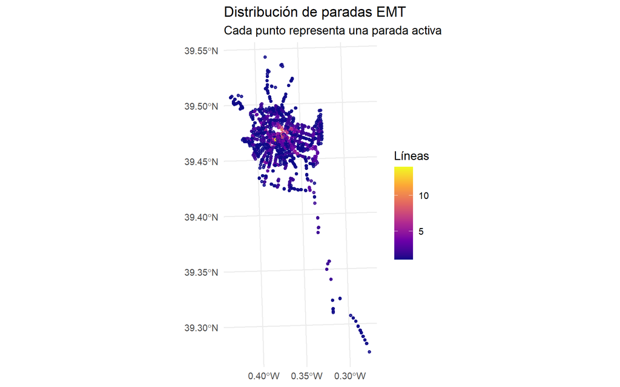

Localización de paradas activas y número de líneas. Geometrías almacenadas en EPSG:25830.

```r
p_mapa
```

Para resumir la concentración se construye una cuadrícula de 250 × 250 metros y se asigna cada parada a una única celda. Se muestran únicamente las celdas ocupadas. Las cifras representan **paradas por celda**, equivalentes a multiplicar por 16 para obtener paradas/km²; no representan demanda, cobertura poblacional ni ausencia de servicio en todo el municipio. La extensión, origen y tamaño de la malla afectan al resultado y se deben acordar con el equipo para P5.

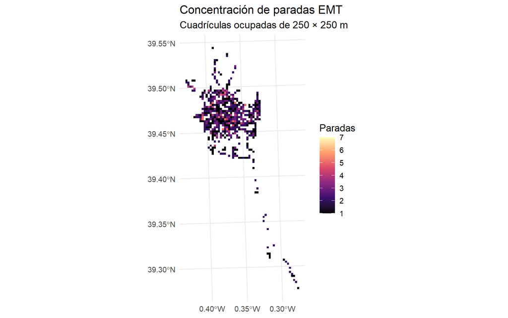

Número de paradas en celdas ocupadas de 250 metros de lado.

```r
p_densidad
```

```r
knitr::kable(as.data.frame(t(summary(celdas$paradas))), digits = 2,
             caption = "Paradas por celda ocupada")
```

Paradas por celda ocupada

| Var1 | Var2 | Freq |
| --- | --- | --- |
| A | Min. | 1.00 |
| A | 1st Qu. | 1.00 |
| A | Median | 2.00 |
| A | Mean | 2.05 |
| A | 3rd Qu. | 3.00 |
| A | Max. | 7.00 |

Hay 563 celdas ocupadas y la más poblada contiene 7 paradas. El mapa permite detectar agrupaciones de la red, pero sin límites municipales o una base cartográfica no permite atribuir rigurosamente cada celda a un barrio concreto.

# 4 Discusión y conclusiones

En la copia analizada, la mayoría de paradas tiene pocas líneas y unas pocas concentran bastantes. Las paradas mejor conectadas identificadas por su denominación ofrecen lugares concretos para estudiar posibles coincidencias con el tráfico. La malla revela una distribución espacial desigual, aunque no permite inferir causalidad ni hacer afirmaciones sobre población atendida, tiempos de espera, frecuencia o demanda.

La instantánea carece de fecha original confirmada y no se ha validado su cobertura histórica ni la equivalencia de nombres de línea a lo largo del tiempo. El contraste de identificadores con el servicio municipal verifica la cobertura de IDs en ese momento, no garantiza que todos los atributos fueran idénticos. La integración posterior debe verificar las fechas y CRS del tráfico y las decisiones sobre radios y cuadrículas. Los datos limpios se entregan como CSV y GeoPackage para facilitarla.

# 5 Referencias

Ayuntamiento de València. [EMT: información geográfica de las paradas de autobús](https://opendata.vlci.valencia.es/dataset/emt). Servicio: [capa EMT, MapServer 226](https://geoportal.valencia.es/server/rest/services/OPENDATA/Trafico/MapServer/226). Consulta de contraste: 2 de noviembre de 2026. [Licencia CC BY 4.0](https://creativecommons.org/licenses/by/4.0/deed.es).